# **Bellabeat Marketing Strategy - Google Data Analytics Capstone**

Abdullahi Olapojoye

## **Bellabeat - A women-centric wellness technology company to beat**

Bellabeat is a women-centric wellness technology company that develops wearables and accompanying products that monitor biometric and lifestyle data to help women better understand how their bodies work and make healthier choices.It was founded in 2013 by UrškaSršen and Sando Mur.More information can be found [here](https://bellabeat.com/)

## **Primary Stakeholders**:

**UrškaSršen**: Bellabeat’s cofounder and Chief Creative Officer(CCO)

**Sando Mur** – Mathematician and Bellabeat’s cofounder

## **Secondary Stakeholders:**

**Bellabeat Marketing Analytics Team**: A data analyst team that collects, analyzes, and reports data that helps guide Bellabeat’s marketing strategy

## **Business Task**

Analyze data from non-Bellabeat products users to gain valuable insights about users habits that can guide the Bellabeat marketing strategy.

## **Tools Used**:

- **R & SQL** - Data preparation, Cleaning and Analysis
- **R & Google Sheets** - Visualization and Pivot Table

## **Data Preparation**

**Dataset Name**: [Fitbit Fitness Tracker Data](https://www.kaggle.com/datasets/arashnic/fitbit) was downloaded from Kaggle platform.

**Accessibility and licensing**: Published by MöBIUS to Kaggle.com under the Public Domain Creative Common License.

**Brief Summary** : The data contains personal fitness tracker from thirty Fitbit users. The datasets contains 18 csv files. It contains personal fitness tracker data including daily physical activity, heart rate and sleep data that can be used to explore the user habits.

**Limitations of the data**: The data was collected in 2016 making the dataset outdated for current trend analysis and the timeframe for the analysis is just 31 days, which is relatively a small duration. The sample size is only 30 users which itself could create a sample bias.

## **Data Cleaning**

The following cleaning activities were carried out:

- Inspect datasets
- Transform data
- Deal with null values
- Deal with inconsistent data formats

### Install R packages:

```r
#Packages used
install.packages("ggcorrplot")
library("ggcorrplot")
install.packages("ggpubr")
library("ggpubr")
install.packages("sqldf")
library("sqldf")
install.packages("tidyverse")
library("tidyverse")
```

### Load the datasets:

18 csv files from the Fitbit data was loaded

```r
daily_activity_data <- read_csv("Fitabase Data 4.12.16-5.12.16/dailyActivity_merged.csv")
daily_calories_data <- read_csv("Fitabase Data 4.12.16-5.12.16/dailyCalories_merged.csv")
daily_intensities_data <- read_csv("Fitabase Data 4.12.16-5.12.16/dailyIntensities_merged.csv")
daily_steps_data <- read_csv("Fitabase Data 4.12.16-5.12.16/dailySteps_merged.csv")
hourly_calories_data <- read_csv("Fitabase Data 4.12.16-5.12.16/hourlyCalories_merged.csv")
hourly_intensities_data <- read_csv("Fitabase Data 4.12.16-5.12.16/hourlyIntensities_merged.csv")
hourly_steps_data <- read_csv("Fitabase Data 4.12.16-5.12.16/hourlySteps_merged.csv")
minute_calories_data_narrow <- read_csv("Fitabase Data 4.12.16-5.12.16/minuteCaloriesNarrow_merged.csv")
minute_intensities_data_narrow <- read_csv("Fitabase Data 4.12.16-5.12.16/minuteIntensitiesNarrow_merged.csv")
minute_steps_data_narrow <- read_csv("Fitabase Data 4.12.16-5.12.16/minuteStepsNarrow_merged.csv")
minute_calories_data_Wide <- read_csv("Fitabase Data 4.12.16-5.12.16/minuteCaloriesWide_merged.csv")
minute_intensities_data_Wide <- read_csv("Fitabase Data 4.12.16-5.12.16/minuteIntensitiesWide_merged.csv")
minute_steps_data_Wide <- read_csv("Fitabase Data 4.12.16-5.12.16/minuteStepsWide_merged.csv")
minute_METS_data_Narrow <- read_csv("Fitabase Data 4.12.16-5.12.16/minuteMETsNarrow_merged.csv")
minute_sleep_data <- read_csv("Fitabase Data 4.12.16-5.12.16/minuteSleep_merged.csv")
sleep_day_data <- read_csv("Fitabase Data 4.12.16-5.12.16/sleepDay_merged.csv")
heartrate_seconds_data <- read_csv("Fitabase Data 4.12.16-5.12.16/heartrate_seconds_merged.csv")
weight_data <- read_csv("Fitabase Data 4.12.16-5.12.16/weightLogInfo_merged.csv")
```

### Inspecting the loaded data:

```r
#glimpse of the data
head(daily_activity_data)
head(daily_calories_data)
head(daily_intensities_data)
head(daily_steps_data)
head(sleep_day_data)
head(weight_data)
head(hourly_steps_data)
head(hourly_intensities_data)
head(hourly_calories_data)
head(minute_calories_data_narrow)
head(minute_calories_data_Wide)
head(minute_intensities_data_narrow)
head(minute_intensities_data_Wide)
head(minute_steps_data_narrow)
head(minute_steps_data_Wide)
head(heartrate_seconds_data)
head(minute_METS_data_Narrow)
head(minute_sleep_data)
#check the dimension
dim(daily_activity_data)
dim(daily_calories_data)
dim(daily_intensities_data)
dim(daily_steps_data)
dim(sleep_day_data)
dim(weight_data)
dim(hourly_steps_data)
dim(hourly_intensities_data)
dim(hourly_calories_data)
dim(minute_calories_data_narrow)
dim(minute_calories_data_Wide)
dim(minute_intensities_data_narrow)
dim(minute_intensities_data_Wide)
dim(minute_steps_data_narrow)
dim(minute_steps_data_Wide)
dim(heartrate_seconds_data)
dim(minute_METS_data_Narrow)
dim(minute_sleep_data)
```

### Data Transformation:

```r
# Create a new column TotalActiveMinutes which is the sum of columns "VeryActiveMinutes", "FairlyActiveMinutes", "LightlyActiveMinutes":
daily_activity_data <- daily_activity_data %>%
  rowwise() %>%
  mutate(
    TotalActiveMinutes = sum(c(VeryActiveMinutes, FairlyActiveMinutes, LightlyActiveMinutes)))

# Removing the columns 5 to 13 because they are already figured in the dataset:
daily_activity_final <- daily_activity_data %>%
  select(-c(5:13))

#merging daily_activity_data and sleep_day_data:
daily_data_final <- merge(daily_activity_final, sleep_day_data, by="Id")

#Previewing the new transformed dataframe:
head(daily_data_final)

#merge daily activity with weight:
daily_weight_data <- merge(daily_activity_final, weight_data, by="Id")

#Merge hourly_data:
hourly_data <- merge(hourly_calories_data, hourly_intensities_data)
hourly_data_final <- merge(hourly_data, hourly_steps_data)

#Previewing the new dataframe:
head(hourly_data_final)

#Transforming minute datasets
df <- merge(minute_calories_data_narrow, minute_intensities_data_narrow)
minute_datasets_combined <- merge(df, minute_steps_data_narrow)
minute_data_final <- merge(minute_datasets_combined, minute_METS_data_Narrow)

#Previewing the new dataframe:
head(minute_data_final)
```

### Dealing with null values:

```r
# Checking each column of the dataframe daily_data_final for null values:

is.null(daily_data_final$Id)
is.null(daily_data_final$ActivityDate)
is.null(daily_data_final$TotalSteps)
is.null(daily_data_final$TotalDistance)
is.null(daily_data_final$SedentaryMinutes)
is.null(daily_data_final$Calories)
is.null(daily_data_final$TotalActiveMinutes)

# Checking each column of the dataframe hourly_data_combined for null values:

is.null(hourly_data_final$Id)
is.null(hourly_data_final$ActivityHour)
is.null(hourly_data_final$Calories)
is.null(hourly_data_final$TotalIntensity)
is.null(hourly_data_final$AverageIntensity)
is.null(hourly_data_final$StepTotal)

# Checking each column of the dataframe minute_data_combined for null values:

is.null(minute_data_final$Id)
is.null(minute_data_final$ActivityMinute)
is.null(minute_data_final$Calories)
is.null(minute_data_final$Intensity)
is.null(minute_data_final$Steps)
is.null(minute_data_final$METs)
```

### Reformating the data:

```r
#Reformat the data and extract weekdays from date
daily_data_final$ActDate <- strptime(as.character(daily_data_final$ActivityDate), "%m/%d/%Y")
daily_data_final$NewActivityDate <- format(daily_data_final_v2$ActDate, "%Y-%m-%d")
daily_data_final$Week_day <- wday(daily_data_final$NewActivityDate, label=TRUE, abbr = FALSE)
```

**Result of cleaning** :

1. No null or missing values was found in the data
2. The data was reformatted in other to be able to easily extract variables of interest during analysis.
3. Redundant data was removed from the dataset.
4. Data with the same number of rows aand unique Ids were merged.

## **Data Analysis**

After cleaning, the following datasets were analyzed to gain insights:

1. daily_data_final
2. minute_data_final
3. hourly_data_final
4. daily_weight_data

### Number of unique Ids:

```r
# Inspecting the disitnct Id's in each of the four dataframes:

n_distinct(daily_data_final$Id)
n_distinct(hourly_data_final$Id)
n_distinct(minute_data_final$Id)
n_distinct(daily_weight_data$Id)
```

### Tracker Usage Summary

Fitbit users can be classified into four categories

```r
User_sum <- sqldf("SELECT Id,
          COUNT(Id) AS Total_Logged_Uses,
          CASE
          WHEN COUNT(Id) >27 THEN 'Heavy User'
          WHEN COUNT(Id) BETWEEN 16 and 27 THEN 'Light User'
          WHEN COUNT(Id) BETWEEN 1 and 15 THEN 'Fairly Active User'
          WHEN COUNT(Id) == 0 THEN 'Inactive User'
          END AS User_Summary
          FROM daily_activity_data
          GROUP BY Id")
view(User_sum)
```

[Fitness Tracker User Types Chart - Google Sheets](https://docs.google.com/spreadsheets/d/1h1N_XVEpvKQs0zzFCJEprjZNuxvZV4XCiaH5XuV2aFs/edit?usp=sharing)

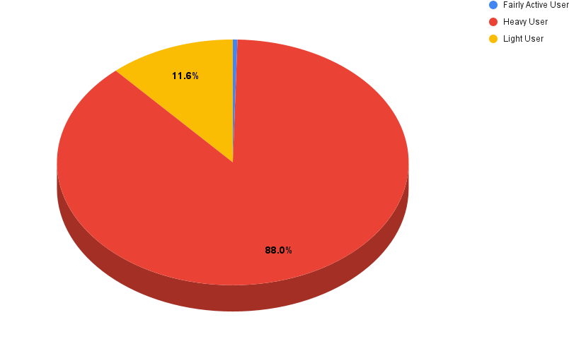

```r
knitr::include_graphics("Plots/Tracker Usage.png")
```

This plot shows that majority of participants use the Fitbit Tracker actively.

### Converting the minutes data to hours and creating new columns in daily_data_final dataframe:

```r
# Adding columns "TotalHoursAsleep","TotalActiveHours", "TotalSedentaryHours":

daily_data_final_v2 <- daily_data_final %>%
  mutate(TotalHoursAsleep = round(TotalMinutesAsleep/60, 1),
         SedentaryHours = round(SedentaryMinutes/60, 1),
         TotalActiveHours = round(TotalActiveMinutes/60, 1),
         TotalHoursInBed = round(TotalTimeInBed/60, 1))

# Previewing the transformed dataframe:
head(daily_data_final_v2)
summary(daily_data_final_v2$TotalHoursAsleep)
summary(daily_data_final_v2$TotalActiveHours)
summary(daily_data_final_v2$SedentaryHours)
summary(daily_data_final_v2$Calories)
summary(daily_data_final_v2$TotalDistance)
summary(daily_data_final_v2$TotalSteps)
summary(daily_data_final_v2$TotalHoursInBed)
```

### Average steps per day:

```r
Avg_Steps_per_day <- sqldf("SELECT Id,
ROUND(AVG(TotalSteps)) AS Avg_Total_Steps,
CASE
WHEN ROUND(AVG(TotalSteps)) < 5000 THEN 'Not recommended'
WHEN ROUND(AVG(TotalSteps)) BETWEEN 5000 AND 7499 THEN 'Fair range'
WHEN ROUND(AVG(TotalSteps)) BETWEEN 7500 AND 9999 THEN 'Recommended range'
WHEN ROUND(AVG(TotalSteps)) > 10000 THEN 'Above recommended range'
END AS User_Type
FROM daily_activity_data
GROUP BY Id")
```

[Average Steps per Day Chart - Google sheets](https://docs.google.com/spreadsheets/d/11phEJxBFuiqXRSWfwyQsvuTQ2nc9o8wrl9qWNawsILk/edit?usp=sharing)

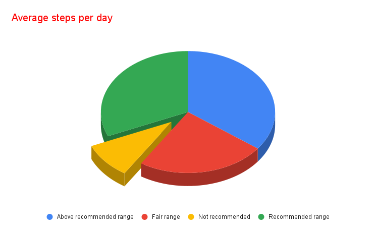

```r
knitr::include_graphics("Plots/Average steps per day.png")
```

The above plot shows that only a small number of users do not not take the minimum required number of steps per day

## Extract day of the week from the daily_activity data dataframe:

```r
daily_data_final_v2$ActDate <- strptime(as.character(daily_data_final_v3$ActivityDate), "%m/%d/%Y")
daily_data_final_v2$NewActivityDate <- format(daily_data_final_v2$ActDate, "%Y-%m-%d")
daily_data_final_v2$Week_day <- wday(daily_data_final_v2$NewActivityDate, label=TRUE, abbr = FALSE)
```

[Realationship between Active hours and Weekdays - Google Sheets](https://docs.google.com/spreadsheets/d/1ysW6v63rrpAV1dIHdShGTPqQnBwBZtIldAy649SGPEE/edit?usp=sharing)

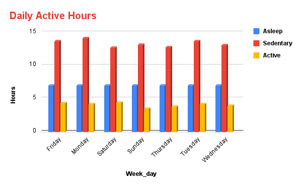

```r
knitr::include_graphics("Plots/Daily Active Hours.png")
```

```r
Avg_steps_per_hour <- sqldf("SELECT
ActivityHour,
ROUND(AVG(StepTotal)) AS Average_Steps_By_Hour
FROM hourly_data_final
GROUP BY ActivityHour
ORDER BY Average_Steps_By_Hour DESC")
```

### Extract hours of the day from the hourly_data dataframe:

```r
Avg_steps_per_hour$Hour <- strptime(as.character(Avg_steps_per_hour$ActivityHour), "%m/%d/%Y %H:%M:%S")
Avg_steps_per_hour$Hours <- format(Avg_steps_per_hour$Hour, "%Y-%m-%d %H:%M:%S")
Avg_steps_per_hour$ActiveHour <- hour(Avg_steps_per_hour$Hours)
```

[Average Steps per Hour Chart - Google sheets](https://docs.google.com/spreadsheets/d/1RLp6w67JyP7C0GdCEXbH0lhUcG4kKiTXInmfG4cf8-M/edit?usp=sharing)

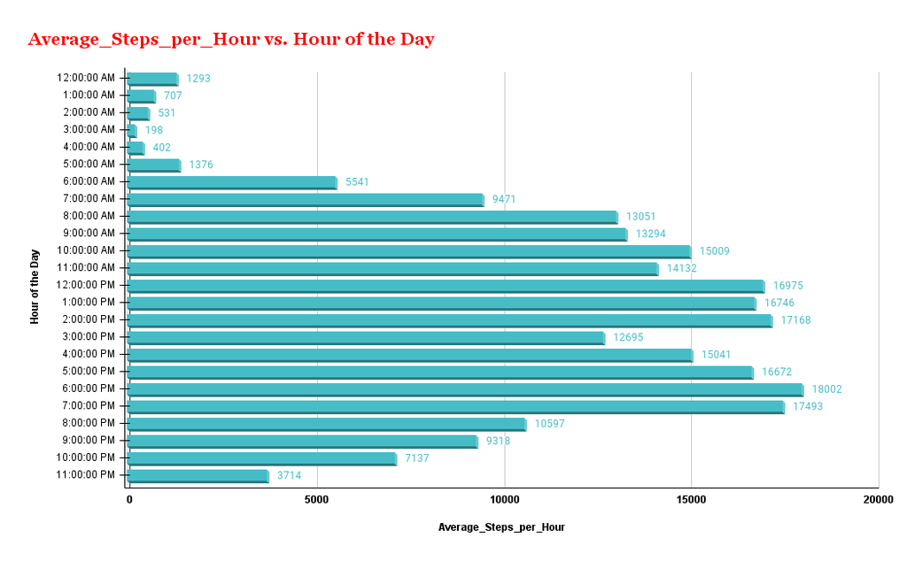

```r
knitr::include_graphics("Plots/Average_Steps_per_Hour vs. Hour of the Day.png")
```

This plot pints to the fact that Fitbit users are more active in the afternoon and evening. Less activity is seen in the night.

### Aggregate data on relationships between calories, sleep and steps:

```r
### Case_when() to create new variable to aggregate the data from dataframes: daily_data_combined_v2 and weight_info_v2:

daily_data_final_v3 <- daily_data_final_v2 %>%
  mutate(sleep_summary = case_when(TotalHoursAsleep>=6 & TotalHoursAsleep <=8   ~ "6-8", TotalHoursAsleep >8 ~ ">8", TRUE ~ "<6"),
         calories_burned = case_when(Calories>=1800 & Calories <=2900   ~ "Medium(1800-2900)", Calories > 2900 ~ "High(>2900)", TRUE ~ "Low(0-1800)"),
         total_steps_taken = case_when(TotalSteps>=4600 &  TotalSteps <=8100   ~ "Steps(4600-8100)", TotalSteps>8100 &  TotalSteps <11300   ~ "Steps(8100-11300)", TotalSteps >= 11300 ~ "Steps(>11300)", TRUE ~ "Steps(<4660)"),
         total_distance_travelled = case_when(TotalDistance>=3 &  TotalDistance <=6   ~ "Distance(3-6)", TotalDistance>6 &  TotalDistance <=8   ~ "Distance(6-8)", TotalDistance > 8 ~ "Distance(>8)", TRUE ~ "Distance(<3)"),
         sedentary_hours_spent= case_when(SedentaryHours>=11 & SedentaryHours <=13   ~ "Sedentary Hours(11-13)",  SedentaryHours > 13 ~ "Sedentary Hours(>13)", TRUE ~ "Sedentary Hours(<11)"),
         total_active_hours_spent = case_when(TotalActiveHours>=3.2 & TotalActiveHours <=5.2   ~ "Average(3.2-5.2)",  TotalActiveHours > 5.2 ~ "High(>5.2)", TRUE ~ "Low(<3.2)"))

daily_weight_data_v2 <- daily_weight_data %>%
  mutate(weight_category = case_when(WeightKg>62 & WeightKg <85  ~ "62-85", WeightKg >=85 ~ ">85", TRUE ~ "<62"))

# Sorting the observations of the above aggregated data frames respectively:
daily_data_final_v3$sleep_summary <- factor(daily_data_final_v3$sleep_summary,levels = c("<6", "6-8", ">8"))
daily_data_final_v3$total_distance_travelled <- factor(daily_data_final_v3$total_distance_travelled,levels = c("Distance(<3)", "Distance(3-6)", "Distance(6-8)", "Distance(>8)"))
daily_data_final_v3$sedentary_hours_spent <- factor(daily_data_final_v3$sedentary_hours_spent,levels = c("Sedentary Hours(<11)", "Sedentary Hours(11-13)", "Sedentary Hours(>13)"))
daily_data_final_v3$total_steps_taken <- factor(daily_data_final_v3$total_steps_taken,levels = c("Steps(<4660)", "Steps(4600-8100)", "Steps(8100-11300)", "Steps(>11300)"))

daily_weight_data_v2$WeightKg <- factor(daily_weight_data_v2$WeightKg, levels = c("<62", "62-85", ">85"))
```

### Correlation between time on bed and time asleep:

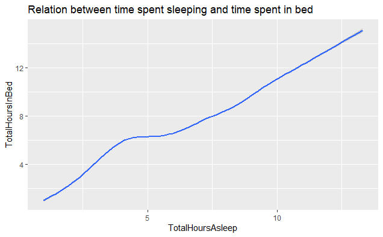

```r
ggplot(data = daily_data_final_v3)+
  geom_smooth(mapping = aes(x=TotalHoursAsleep, y=TotalHoursInBed))+ labs(title="Relation between time spent sleeping and time spent in bed")
```

As expected, there is a positive relationship between the total hours in bed and the total hours asleep as shown in the figure above.

```r
#Relationship between steps and weight
BMI_Steps <- sqldf("SELECT dwd.BMI,ddf.TotalSteps
FROM daily_weight_data AS dwd INNER JOIN daily_activity_data AS ddf ON dwd.Id = ddf.Id")

#view(BMI_Steps)
```

### Relationship between weight and total distance compared by mode of report:

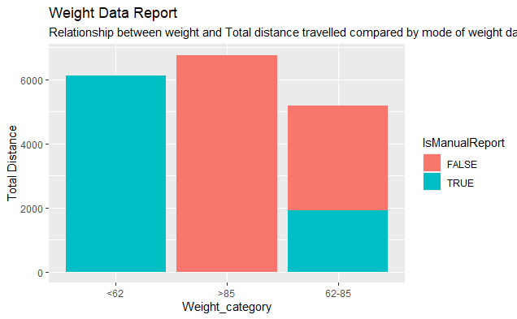

```r
ggplot(data=daily_weight_data_v2)+
  geom_col(mapping=aes(x = weight_category, y = TotalDistance, fill=IsManualReport))+
  #facet_grid(~IsManualReport)+
  labs(title="Weight Data Report", subtitle="Relationship between weight and Total distance travelled compared by mode of weight data report",
       x = "Weight_category", y = "Total Distance")
```

### Relationship between Distance travelled and Calories burned in a day:

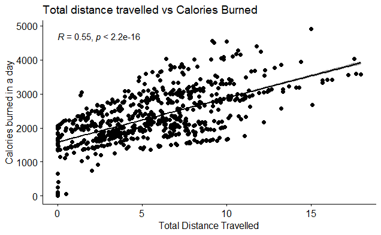

```r
ggscatter(daily_data_final_v3, x = "TotalDistance", y = "Calories",
          add = "reg.line", conf.int = TRUE,
          cor.coef = TRUE, cor.method = "pearson",
          title = "Total distance travelled vs Calories Burned",
          xlab = "Total Distance Travelled", ylab = "Calories burned in a day")
```

It can be deduced from the plot above that more calories are burned per day astotal distance travelled increases.

### Relationship between sleep and calories burned compared by distance travelled:

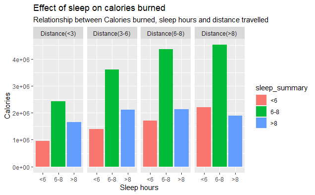

```r
ggplot(data=daily_data_final_v3)+
  geom_col(mapping=aes(x = sleep_summary, y = Calories, fill=sleep_summary))+
  facet_grid(~total_distance_travelled)+
  labs(title="Effect of sleep on calories burned", subtitle="Relationship between Calories burned, sleep hours and distance travelled",
       x = "Sleep hours", "Calories Burned")
```

### Relationship between Intensity of workout per hour and calories burned per hour:

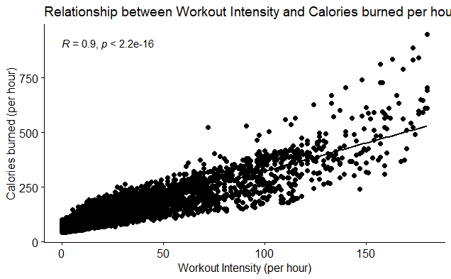

```r
ggscatter(hourly_data_final, x = "TotalIntensity", y = "Calories",
          add = "reg.line", conf.int = TRUE,
          cor.coef = TRUE, cor.method = "pearson",
          add.params = list(color = "black",
                            fill = "yellow"),
          title = "Relationship between Workout Intensity and Calories burned per hour",
          xlab = "Workout Intensity (per hour)", ylab = "Calories burned (per hour)")
```

## Recommendations:

- Bellabeat should create a “Reward system” in their products that praises the users whenever they meet up with the recommended daily activities and challenge them to do more when they don’t meet up.
- The marketing team should make campaigns about the fitness benefits of good sleep and the importance of tracking it.
- Bellabeat can add an innovative way of recording weight data. Many of the participants recorded their weight data manually.
- In order to reduce the sedentary minutes, notify the users to take steps and perform some other beneficial activities in the morning.
- The data does not contain information about the gender of the particpants. I therefore recommend that Bellabeat should can women-centric data and redo the analysis.